# ggplot2: An introduction

## Libraries

We’re going to use several new packages today. Install the following via the package manager:

- palmerpenguins
- RColorBrewer
- patchwork

```r
library(tidyverse)  # loads ggplot2, dplyr, and others
library(palmerpenguins)  # easy access to the penguins data
library(RColorBrewer) # color palettes
library(patchwork) # laying out sub-figures
```

## References

There are lots of ggplot2 tutorials on the web, but the ggplot2 website and book are definitive resources if you want to understand how to use and extend ggplot2:

- ggplot2 website – https://ggplot2.tidyverse.org/
- ggplot2 book – https://ggplot2-book.org/

## Data

We’ll be primarily using the now familiar Palmer penguins data set to illustrate ggplot basics. But first, we’ll remove any missing values to simplify our plots:

```r
# We're dropping all rows with NA values for illustration purposes
# Don't do this out of habit for your own data though!
tidy_data <- drop_na(penguins)
```

## Required layers: Data, geometry, and aesthetics

Every ggplot2 figure requires us to define three elements:

1. Data, in the form of a data frame
2. Aesthetics, specifying what gets variables mapped to the various aspects of the geometric mapping
3. One or more geometric mappings that specify the plot type(s)

## Layer 1 - Data

Remember - ggplot works in layers!

We start with calling ggplot as a function with parenthesis.

The first layer is the data - this gives us an empty canvas to build onto. In this case, we specify our penguins dataset within the parenthesis using `data = penguins`

*Note: You can omit the `data =` part and just call a data frame like `ggplot(tidy_data)`, but it is always good to clearly specify what your code is doing!*

```r
ggplot(data = tidy_data)
```

This generated have a blank canvas!

## Layer 2 - Aesthetics = Mapping

In ggplot, ‘aesthetics’ refers to the mapping of columns of our dataset onto aesthetic attributes of our plot.

In this case, the attributes we want to specify are the x and y coordinates of the plot.

```r
ggplot(data = tidy_data,
       mapping = aes(x = body_mass_g))
```

Now we can see that body mass hass appeared on the x-axis of our canvas!

However, there still isn’t any data shown. We need to specify a **geometry** that gives our data a shape to display

## Layer 3 - Geometries

Like an oil painting, we are building in layers on top of what we have already done.

In ggplot, we use the + operator after the `ggplot()` call to tell R that the following layer is part of the plot.

Let’s start with a basic **density plot**. A density plot estimates the probability distribution of a variable of interest. The corresponding Geom for generating such a plot is `geom_density`. .

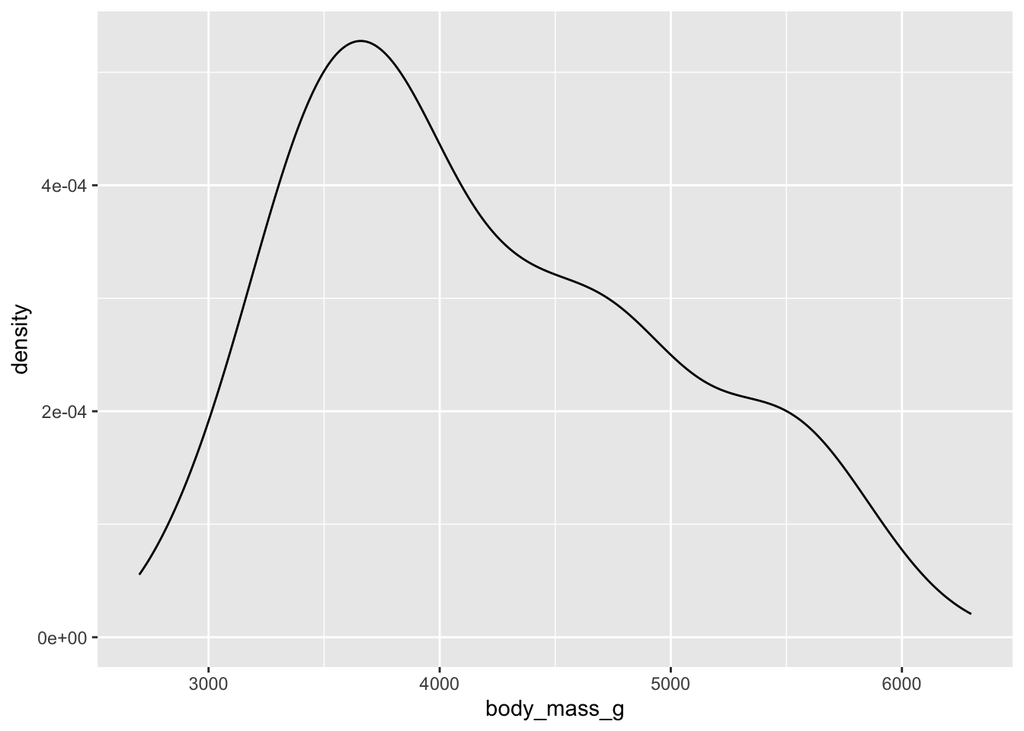

```r
ggplot(data = tidy_data, mapping = aes(x = body_mass_g)) +
  geom_density()
```

You will notice that even though we didn’t specify a y-axis variable, the `geom_density` function automatically the y-values of the values we specified in the x-axis call).

## Multiple ways to specify ggplot layers

- Aesthetics specified in a `ggplot` call, are inherited by all geoms. Let’s illustrate this by adding a second geom to our density plot:

```r
# both geoms inherit the aesthetics
ggplot(tidy_data,
       aes(x = body_mass_g)) +
  geom_density() +
  geom_rug()
```

The `geom_rug` function can be very useful in visualizations like this, since it helps show the marginal distributions within the data.

- Aesthetics can be specified in an independent call to the `aes()` function:

```r
# again aesthetics inherited by geoms that follow
ggplot(tidy_data) +
  aes(x = body_mass_g) +
  geom_density() +
  geom_rug()
```

- Aesthetics can be specified in the geoms themselves:

```r
# here each geom needs to redefine the aesthetics
ggplot(tidy_data) +
  geom_density(aes(x = body_mass_g)) +
  geom_rug(aes(x = body_mass_g, color = species))
```

## ggplot elements can be assigned to variables

ggplot layers can be assigned to variables for further manipulation:

```r
data_layer <- ggplot(tidy_data)
aes_layer <- aes(x = body_mass_g)

my_plot <-
  data_layer +
  aes_layer +
  geom_density()

my_plot
```

## Bar plot for representing categorical variables

A density plot is an appropriate depiction of an probability distribution for continuous variables, but not so for categorical variables.

For a variable like species, a basic **bar plot** with height corresponding to the count of the data values is more appropriate. The geom for this is `geom_bar()`

```r
ggplot(data = tidy_data, mapping = aes(x = species)) +
  geom_bar()
```

## Two variables

Let’s add a second variable to our density plots by using color to represent the species column of our data frame:

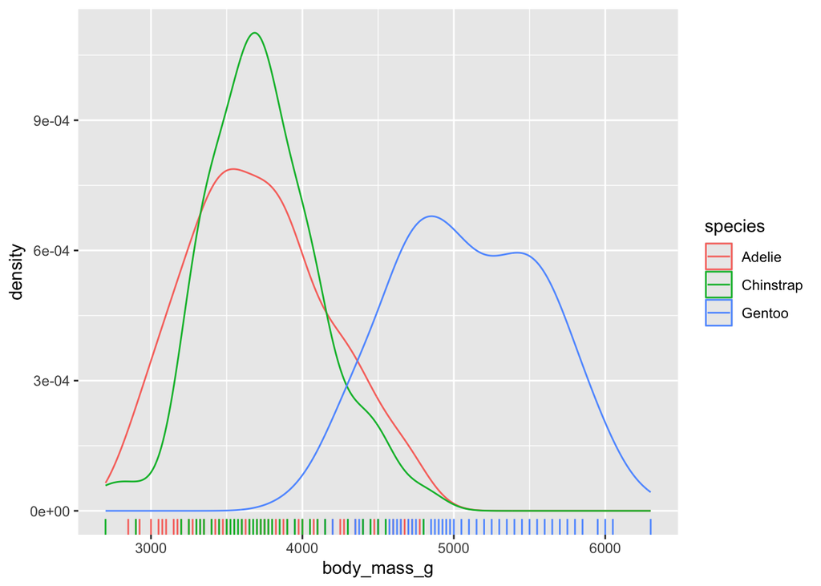

```r
ggplot(data = tidy_data,
       mapping = aes(x = body_mass_g,
                     color = species)) +
  geom_density() +
  geom_rug()
```